# Chosen Sample

Matthew Bone

3/15/2021

This report takes a look the chosen sample from 12706-fulltext.txt. The sample includes all webpages that are from the domains below and from the dates below.

**Domains filtered on:**

‘https://www.mypaperonline.com’ (filtered by ‘/category/the-morristown-news’ in a post-extraction step)

‘https://www.newbrunswicktoday.com’

‘https://www.newarkblack.com’

‘http://www.mypaperonline.com’ (filtered by ‘/category/the-morristown-news’ in a post-extraction step)

‘http://www.newbrunswicktoday.com’

‘http://www.newarkblack.com’

‘mypaperonline.com’ (filtered by ‘/category/the-morristown-news’ in a post-extraction step)

‘newbrunswicktoday.com’

‘newarkblack.com’

‘www.mypaperonline.com’ (filtered by ‘/category/the-morristown-news’ in a post-extraction step)

‘www.newbrunswicktoday.com’

‘www.newarkblack.com’

**Dates filtered on:**

‘20191013’ (none found)

‘20191104’ (none found)

‘20191001’

‘20191030’

‘20191024’

‘20190927’ (none found)

‘20191012’

‘20190930’

‘20191002’ (none found)

‘20191003’ (none found)

**Important Findings:** There don’t seem to be any webpages from these three sources on 10/13, 11/04, 9/27, 10/02, or 10/03 in the dataset. Additionally, there are too few pages from www.mypaperonline.com/category/the-morristown-news for useful analysis.

## Quick Numbers

Number of Articles: 1092

Number of Unique Domains: 4

Number of Unique URLs: 307

```
## # A tibble: 6 x 4
##   date       domain      url                         text
##   <date>     <chr>       <chr>                       <chr>
## 1 2019-10-24 newbrunswi~ https://newbrunswicktoday.~ "New Brunswick Today Hello~
## 2 2019-10-30 newbrunswi~ https://newbrunswicktoday.~ "Governor Christie Nominat~
## 3 2019-10-12 www.mypape~ https://www.mypaperonline.~ "The Morristown News Archi~
## 4 2019-10-12 www.newark~ http://www.newarkblack.com/ "NewarkBlack.com - Newark ~
## 5 2019-10-12 www.newark~ http://www.newarkblack.com/ "�\b"
## 6 2019-10-12 www.newark~ http://www.newarkblack.com~ "You searched for {search_~
```

## Counts by Domain

| domain | count |
| --- | --- |
| newbrunswicktoday.com | 246 |
| www.mypaperonline.com | 4 |
| www.newarkblack.com | 368 |
| www.newbrunswicktoday.com | 474 |

## Counts by Date and Domain

| date | domain | count |
| --- | --- | --- |
| 2019-09-30 | newbrunswicktoday.com | 1 |
| 2019-09-30 | www.mypaperonline.com | 1 |
| 2019-09-30 | www.newarkblack.com | 14 |
| 2019-09-30 | www.newbrunswicktoday.com | 111 |
| 2019-10-01 | newbrunswicktoday.com | 60 |
| 2019-10-01 | www.newarkblack.com | 81 |
| 2019-10-01 | www.newbrunswicktoday.com | 8 |
| 2019-10-12 | newbrunswicktoday.com | 61 |
| 2019-10-12 | www.mypaperonline.com | 1 |
| 2019-10-12 | www.newarkblack.com | 90 |
| 2019-10-12 | www.newbrunswicktoday.com | 118 |
| 2019-10-24 | newbrunswicktoday.com | 62 |
| 2019-10-24 | www.mypaperonline.com | 1 |
| 2019-10-24 | www.newarkblack.com | 94 |
| 2019-10-24 | www.newbrunswicktoday.com | 118 |
| 2019-10-30 | newbrunswicktoday.com | 62 |
| 2019-10-30 | www.mypaperonline.com | 1 |
| 2019-10-30 | www.newarkblack.com | 89 |
| 2019-10-30 | www.newbrunswicktoday.com | 119 |

## Date Distribution

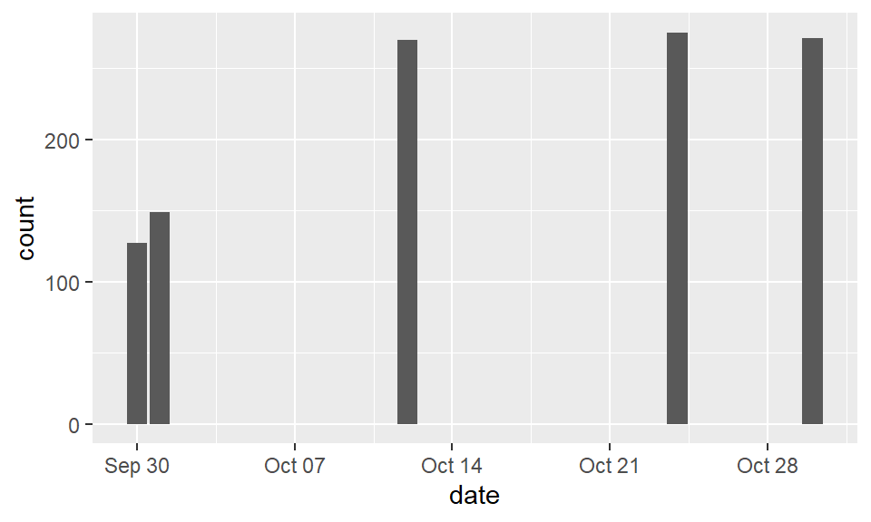

# Filtered by Domains but not Dates

I additionally extracted all data from the given websites (filtered on domain list above) to see if there’s a significant amount of data to be used on other dates. It nearly doubles the count of the web pages in the sample but there’s still very little data from www.mypaperonline.com/category/the-morristown-news.

## Quick Numbers

Number of Articles: 1876

Number of Unique Domains: 4

Number of Unique URLs: 368

```
## # A tibble: 6 x 4
##   date       domain      url                    text
##   <date>     <chr>       <chr>                  <chr>
## 1 2019-10-08 www.newark~ http://www.newarkblac~ "NewarkBlack.com - Newark Afric~
## 2 2019-10-08 www.newark~ http://www.newarkblac~ "�\b"
## 3 2019-10-08 www.newark~ http://www.newarkblac~ "You searched for {search_term_~
## 4 2019-10-08 www.newark~ http://www.newarkblac~ "Advertise - NewarkBlack.com CL~
## 5 2019-10-08 www.newark~ http://www.newarkblac~ "News Archives - NewarkBlack.co~
## 6 2019-10-08 www.newark~ http://www.newarkblac~ "News Archives - Page 2 of 14 -~
```

## Counts by Domain

The counts for newbrunswicktoday.com and www.newbrunswicktoday.com match the counts in 12706-fullurls.txt. However, www.newarkblack.com is not present in the 12706-fullurls.txt file. Since www.mypaperonline.com was filtered by ‘/category/the-morristown-news’, we can’t compare webpage count to what’s in 12706-fullurls.txt.

| domain | count |
| --- | --- |
| newbrunswicktoday.com | 428 |
| www.mypaperonline.com | 14 |
| www.newarkblack.com | 722 |
| www.newbrunswicktoday.com | 712 |

## Counts by Date and Domain

| date | domain | count |
| --- | --- | --- |
| 2019-09-30 | newbrunswicktoday.com | 1 |
| 2019-09-30 | www.mypaperonline.com | 1 |
| 2019-09-30 | www.newarkblack.com | 14 |
| 2019-09-30 | www.newbrunswicktoday.com | 111 |
| 2019-10-01 | newbrunswicktoday.com | 60 |
| 2019-10-01 | www.newarkblack.com | 81 |
| 2019-10-01 | www.newbrunswicktoday.com | 8 |
| 2019-10-08 | newbrunswicktoday.com | 61 |
| 2019-10-08 | www.mypaperonline.com | 3 |
| 2019-10-08 | www.newarkblack.com | 91 |
| 2019-10-08 | www.newbrunswicktoday.com | 119 |
| 2019-10-12 | newbrunswicktoday.com | 61 |
| 2019-10-12 | www.mypaperonline.com | 1 |
| 2019-10-12 | www.newarkblack.com | 90 |
| 2019-10-12 | www.newbrunswicktoday.com | 118 |
| 2019-10-20 | newbrunswicktoday.com | 61 |
| 2019-10-20 | www.mypaperonline.com | 2 |
| 2019-10-20 | www.newarkblack.com | 91 |
| 2019-10-20 | www.newbrunswicktoday.com | 119 |
| 2019-10-24 | newbrunswicktoday.com | 62 |
| 2019-10-24 | www.mypaperonline.com | 1 |
| 2019-10-24 | www.newarkblack.com | 94 |
| 2019-10-24 | www.newbrunswicktoday.com | 118 |
| 2019-10-25 | newbrunswicktoday.com | 1 |
| 2019-10-25 | www.mypaperonline.com | 1 |
| 2019-10-30 | newbrunswicktoday.com | 62 |
| 2019-10-30 | www.mypaperonline.com | 1 |
| 2019-10-30 | www.newarkblack.com | 89 |
| 2019-10-30 | www.newbrunswicktoday.com | 119 |
| 2019-11-01 | www.mypaperonline.com | 1 |
| 2019-11-01 | www.newarkblack.com | 3 |
| 2019-11-02 | newbrunswicktoday.com | 3 |
| 2019-11-02 | www.mypaperonline.com | 1 |
| 2019-11-02 | www.newarkblack.com | 82 |
| 2019-11-11 | newbrunswicktoday.com | 56 |
| 2019-11-11 | www.mypaperonline.com | 2 |
| 2019-11-11 | www.newarkblack.com | 87 |

## Date Distribution

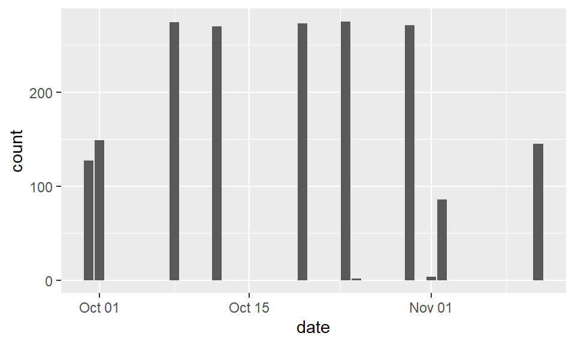